# Warty Sea Cucumber, California

CDFW Project 2016

Adrian Hordyk, University of British Columbia.

June 2017

# Introduction

This OM was built as part of a project with the California Department of Fish and Wildlife to evaluate DLMtool for use in California state-managed marine fisheries.

The goal of the project was to demonstrate an efficient and transparent framework for improving the science for data-limited fisheries and for prioritizing future data collection.

Through close collaboration with CDFW biologists, the project has conducted case studies with four stocks: barred sand bass, Southern California halibut, red sea urchin, and warty sea cucumber. A current project with CDFW, which commenced in February 2018, will update the OM for these cases studies, as well as build OM for several more data-limited fisheries in California.

This document describes the OM for the warty sea cucumber. Several features have been added to DLMtool (e.g., historical MPAs, retention curves and discard mortality) since this OM was built. Default assumptions for these parameters have been made in this OM, and the OM will be updated as part of the 2018 project.

# Operating Model

The OM rdata file can be downloaded from here

Download and import into R using `myOM <- readRDS('OM.rdata')`

## Species Information

**Species**: *Apostichopus parvimensis*

**Common Name**: *Warty Sea Cucumber*

**Management Agency**: CDFW

**Region**: California, USA

**Sponsor**: Resources Legacy Fund

**Latitude**: 34.42083

**Longitude**: -119.69819

## OM Parameters

**OM Name**: Name of the operating model: WSC_CA

**nsim**: The number of simulations: 500

**proyears**: The number of projected years: 50

**interval**: The assessment interval - how often would you like to update the management system? 4

**pstar**: The percentile of the sample of the management recommendation for each method: 0.5

**maxF**: Maximum instantaneous fishing mortality rate that may be simulated for any given age class: 0.8

**reps**: Number of samples of the management recommendation for each method. Note that when this is set to 1, the mean value of the data inputs is used. 1

**Source**: A reference to a website or article from which parameters were taken to define the operating model

See full [report](https://www.datalimitedtoolkit.org/wp-content/uploads/2017/07/Applying-MSE-to-CA-Fisheries-Case-Studies-Recommendations.pdf) for details

# Stock Parameters

### Mortality and age: maxage, R0, M, Msd

**maxage**: The maximum age of individuals that is simulated (there is no plus group ). Single value. Positive integer

Specified Value(s): 30

Maximum age is unknown and was set to 30 years, which is allows for sufficient ages classes for all values of natural mortality.

**R0**: The magnitude of unfished recruitment. Single value. Positive real number

Specified Value(s): 1e+05

Fixed at an arbitrary 100,000.

**M**: Natural mortality rate. Uniform distribution lower and upper bounds. Positive real number

Specified Value(s): 0.2, 0.6

Some research suggests that the natural mortality rates for the California sea cucumber species is relatively high, with a maximum age of 8 - 12 years (Bruckner 2006). However, studies of other holothurian species indicate longevity of at least several decades.

The slow recovery rates of over-exploited sea cucumber stocks suggest that adult natural mortality is relatively low. Bounds for natural mortality were set at 0.2 - 0.6, which relate to a maximum age between 8 and 23 years.

**Msd**: Inter-annual variability in natural mortality rate expressed as a coefficient of variation. Uniform distribution lower and upper bounds. Non-negative real numbers

Specified Value(s): 0, 0.05

No justification provided.

### Natural Mortality Parameters

#### Sampled Parameters

Histograms of simulations of `M`, and `Msd` parameters, with vertical colored lines indicating 3 randomly drawn values used in other plots:

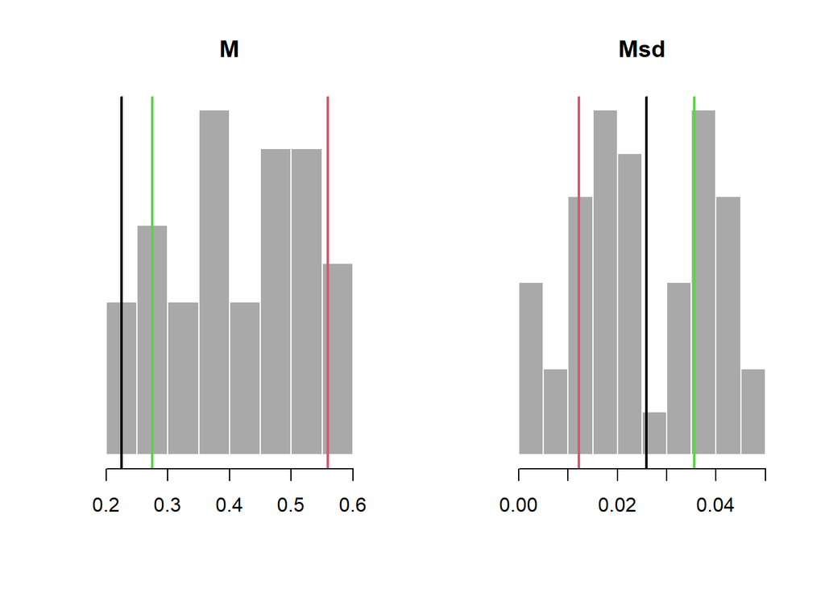

#### Time-Series

The average natural mortality rate by year for adult fish for 3 simulations. The vertical dashed line indicates the end of the historical period:

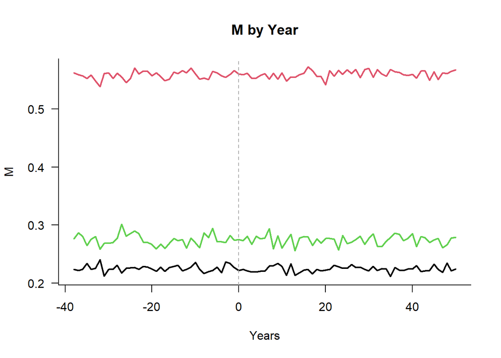

#### M-at-Age

Natural mortality-at-age for 3 simulations in the first historical year, the last historical year (i.e., current year), and the last projected year:

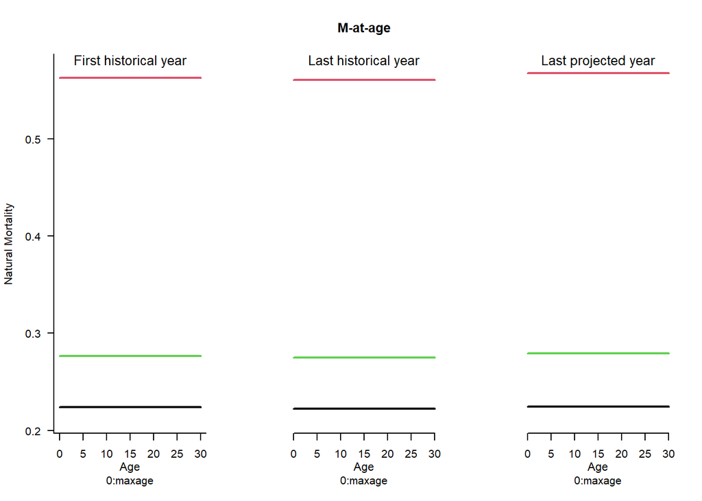

#### M-at-Length

Natural mortality-at-length for 3 simulations in the first historical year, the last historical year (i.e., current year), and the last projected year:

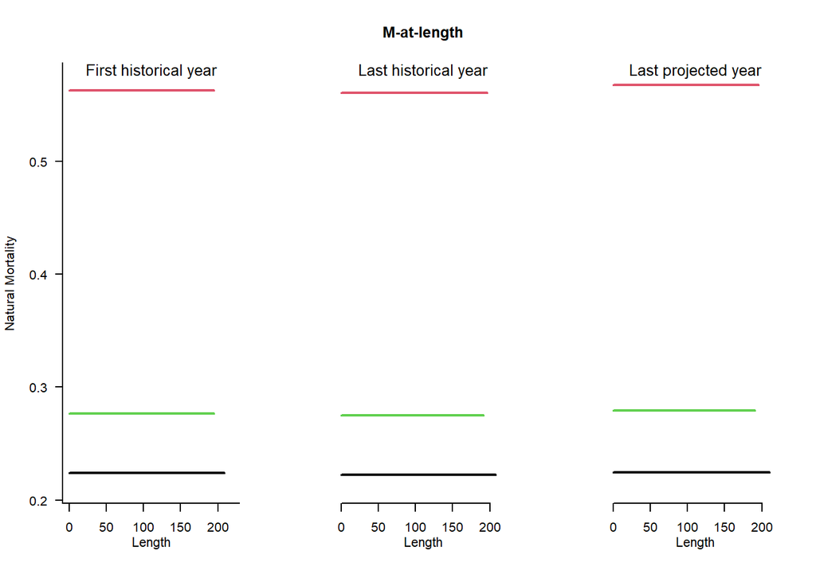

### Recruitment: h, SRrel, Perr, AC

**h**: Steepness of the stock recruit relationship. Uniform distribution lower and upper bounds. Values from 1/5 to 1

Specified Value(s): 0.4, 0.6

See Perr

**SRrel**: Type of stock-recruit relationship. Single value, switch (1) Beverton-Holt (2) Ricker. Integer

Specified Value(s): 1

A Beverton-Holt stock-recruitment was used.

**Perr**: Process error, the CV of log-normal recruitment deviations. Uniform distribution lower and upper bounds. Non-negative real numbers

Specified Value(s): 0.3, 0.6

Little data exists on recruitment trends. Recruitment is believed to be sporadic (Rogers-Bennett and Ono 2007). In the absence of any additional information, the recruitment parameters for the warty sea cucumber were set to the same values as those used for the red sea urchin.

**AC**: Auto-correlation in recruitment deviations rec(t)=AC*rec(t-1)+(1-AC)*sigma(t). Uniform distribution lower and upper bounds. Non-negative real numbers

Specified Value(s): 0.5, 0.9

See Perr

### Recruitment Parameters

#### Sampled Parameters

Histograms of 48 simulations of steepness (`h`), recruitment process error (`Perr`) and auto-correlation (`AC`) for the Beverton-Holt stock-recruitment relationship, with vertical colored lines indicating 3 randomly drawn values used in other plots:

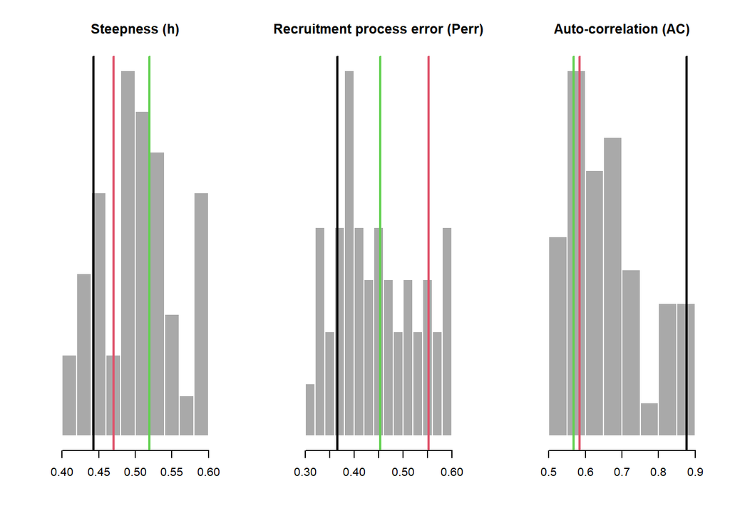

#### Time-Series

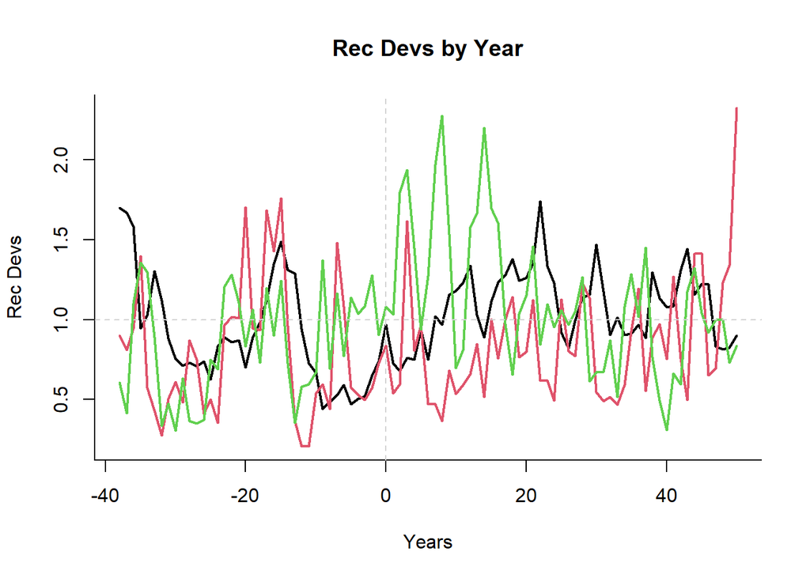

### Growth: Linf, K, t0, LenCV, Ksd, Linfsd

**Linf**: Maximum length. Uniform distribution lower and upper bounds. Positive real numbers

Specified Value(s): 190, 220

The lack of age data and the difficulty in measuring the length of sea cucumber, make estimates of growth problematic. Chavez et al. (2011) report an estimate of Linf of 50 mm using the ELEFAN technique, which is an order of magnitude smaller than other estimates, and perhaps a typographical error in the units.

Bruckner (2006) reports a maximum length of 30 – 40 cm for the warty sea cucumber. The measurement of sea cucumber length is problematic, and depends on the method of measurement. The CDFW measures contracted length of the sea cucumber on the sea floor using diver surveys, and all length measurements reported here for the California WSC are in units of underwater contracted length.

Length frequency data from the CDFW shows a modal length of 100 mm and a maximum length around 220 mm. Based on this information, it was determined that a suitable range for the Linf parameter was 190 – 220 mm.

**K**: von Bertalanffy growth parameter k. Uniform distribution lower and upper bounds. Positive real numbers

Specified Value(s): 0.1, 0.4

Chavez et al. (2011) estimated a K value of 0.6 using the ELEFAN method. No other information appears to exist on the growth curve for the species. There are few details of the ELEFAN analysis in Chavez et al. (2011) and estimates of K can be highly variable using this method. It is difficult to define an appropriate range for this parameter without more detailed studies.

Most literature suggests that growth rates for sea cucumber are relatively slow (Bruckner 2006), whereas a value of K=0.6 would typically be considered relatively fast growth. Based on the knowledge that sea cucumber growth is relatively slow, it was determined that a K of 0.6 is unrealistically high, and the range for this parameter was set at 0.1 – 0.4.

**t0**: von Bertalanffy theoretical age at length zero. Uniform distribution lower and upper bounds. Non-positive real numbers

Specified Value(s): 0, 0

No information exists for estimates of t0, and it was fixed at zero. Length-weight parameters were estimated from survey data provided by the CDFW.

**LenCV**: Coefficient of variation of length-at-age (assumed constant for all age classes). Uniform distribution lower and upper bounds. Positive real numbers

Specified Value(s): 0.1, 0.15

No information, the default value was used.

**Ksd**: Inter-annual variability in growth parameter k expressed as coefficient of variation. Uniform distribution lower and upper bounds. Non-negative real numbers

Specified Value(s): 0, 0.03

No justification provided.

**Linfsd**: Inter-annual variability in maximum length expressed as a coefficient of variation. Uniform distribution lower and upper bounds. Non-negative real numbers

Specified Value(s): 0, 0.03

No justification provided.

### Growth Parameters

#### Sampled Parameters

Histograms of simulations of von Bertalanffy growth parameters `Linf`, `K`, and `t0`, and inter-annual variability in Linf and K (`Linfsd` and `Ksd`), with vertical colored lines indicating 3 randomly drawn values used in other plots:

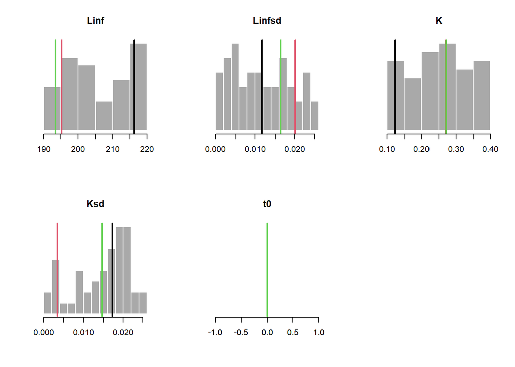

#### Time-Series

The Linf and K parameters in each year for 3 simulations. The vertical dashed line indicates the end of the historical period:

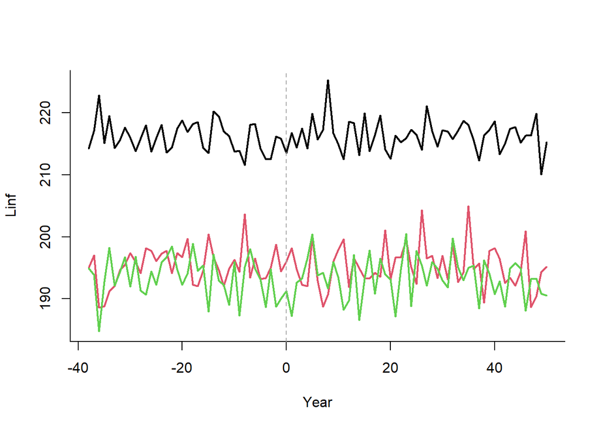

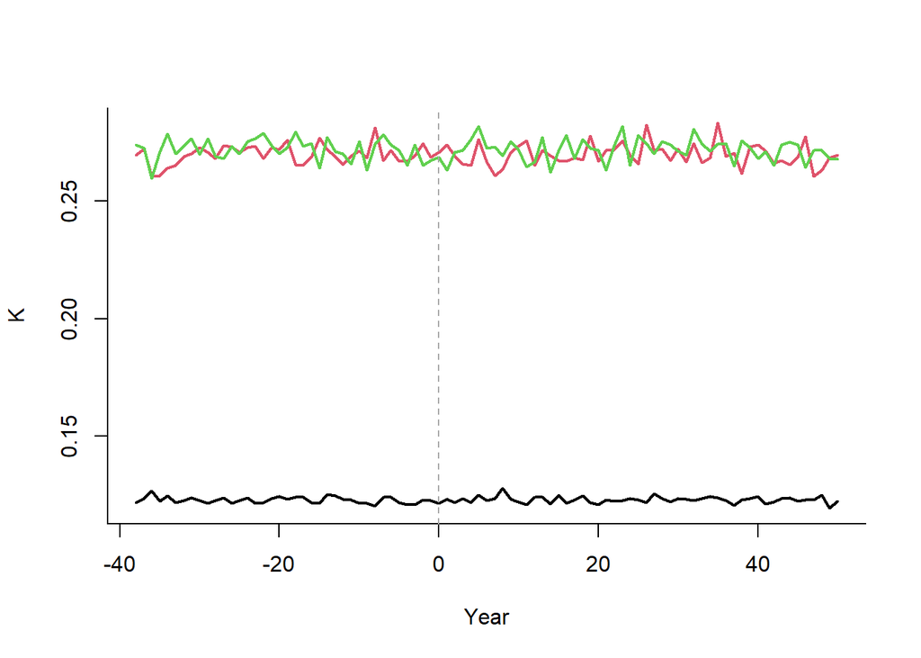

#### Growth Curves

Sampled length-at-age curves for 3 simulations in the first historical year, the last historical year, and the last projection year.

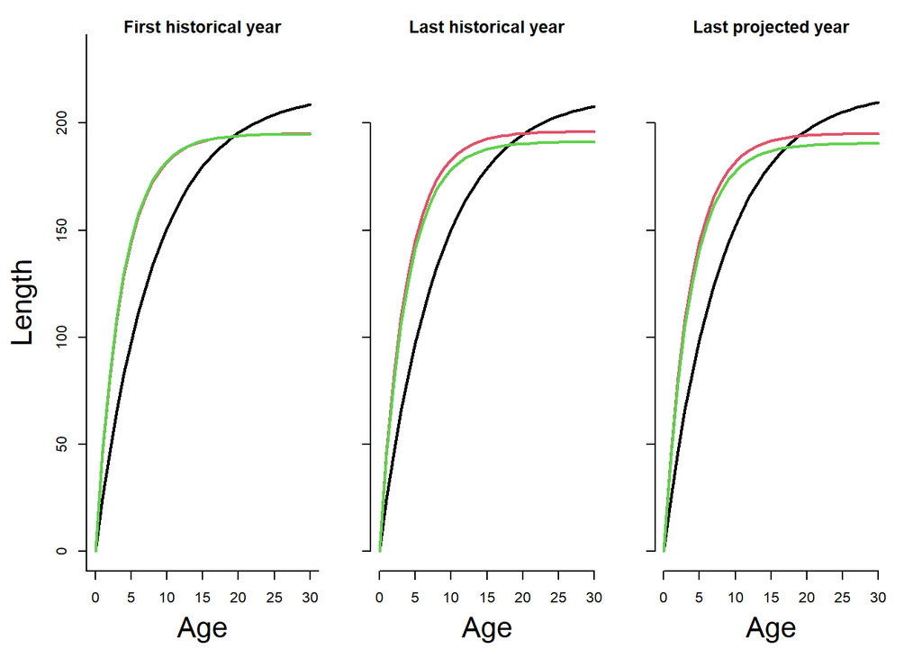

### Maturity: L50, L50_95

**L50**: Length at 50 percent maturity. Uniform distribution lower and upper bounds. Positive real numbers

Specified Value(s): 50, 70

Based on the presence or absence of gonads, the CDFW found females to reach sexual maturity at a total contracted length of 64 mm and at a 53 gram cut body weight (internal viscera and water removed). Males were found to reach sexual maturity at a contracted length of 55 mm and at a 47 gram cut body weight.

Given the uncertainty associated with these parameters, the range for the length at 50% maturity (L50) was set to 50 – 70 mm, and difference between the length at 95% and 50% maturity (L50_95) to 10 – 20 mm.

**L50_95**: Length increment from 50 percent to 95 percent maturity. Uniform distribution lower and upper bounds. Positive real numbers

Specified Value(s): 10, 20

See L50

### Maturity Parameters

#### Sampled Parameters

Histograms of simulations of `L50` (length at 50% maturity), `L95` (length at 95% maturity), and corresponding derived age at maturity parameters (`A50` and `A95`), with vertical colored lines indicating 3 randomly drawn values used in other plots:

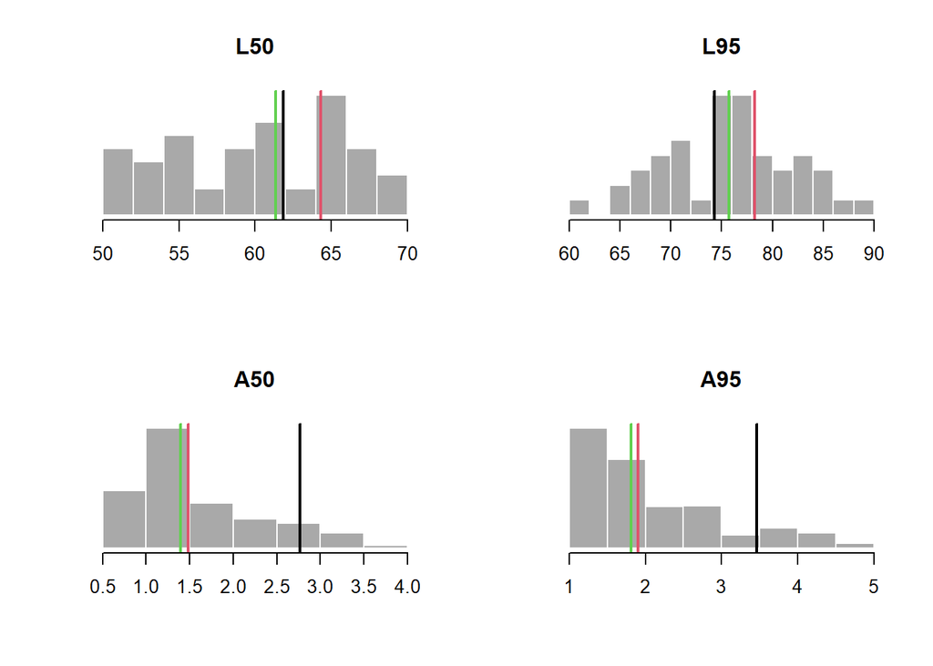

#### Maturity at Age and Length

Maturity-at-age and -length for 3 simulations in the first historical year, the last historical year (i.e., current year), and the last projected year:

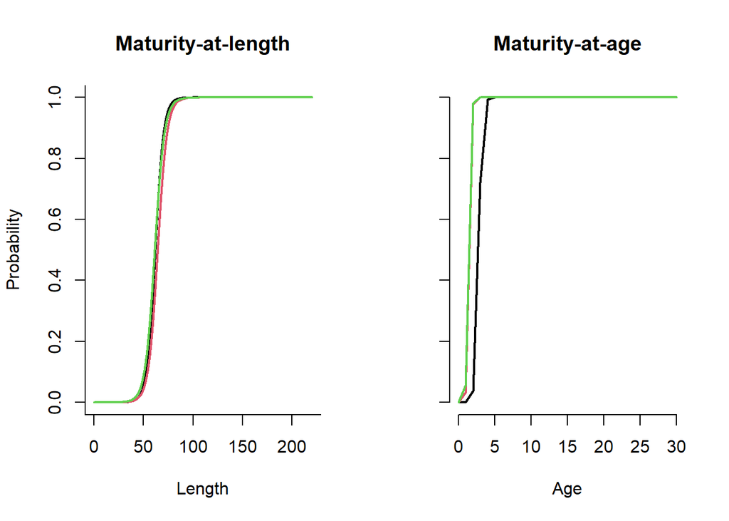

### Stock depletion and Discard Mortality: D, Fdisc

**D**: Current level of stock depletion SSB(current)/SSB(unfished). Uniform distribution lower and upper bounds. Fraction

Specified Value(s): 0.05, 0.4

Declines in catches and divers moving to deeper waters provide some evidence that the abundance of warty sea cucumber may be somewhat lower than in the past. Dive log analysis also suggests that CPUE has decreased from 2005 – 2012.

However, there is no estimate of current depletion, and the range for this parameter was set to 0.05 – 0.40, which allows for the possibility of a stock at very low size (5% of unfished biomass) as well a stock at much higher levels (40% of unfished biomass).

**Fdisc**: Fraction of discarded fish that die. Uniform distribution lower and upper bounds. Non-negative real numbers

Specified Value(s): 0, 0

Discard mortality was not included in DLMtool at the time this OM was built. Recent versions of DLMtool now include discard mortality.

### Depletion and Discard Mortality

#### Sampled Parameters

Histograms of simulations of depletion (spawning biomass in the last historical year over average unfished spawning biomass; `D`) and the fraction of discarded fish that are killed by fishing mortality (`Fdisc`), with vertical colored lines indicating 3 randomly drawn values.

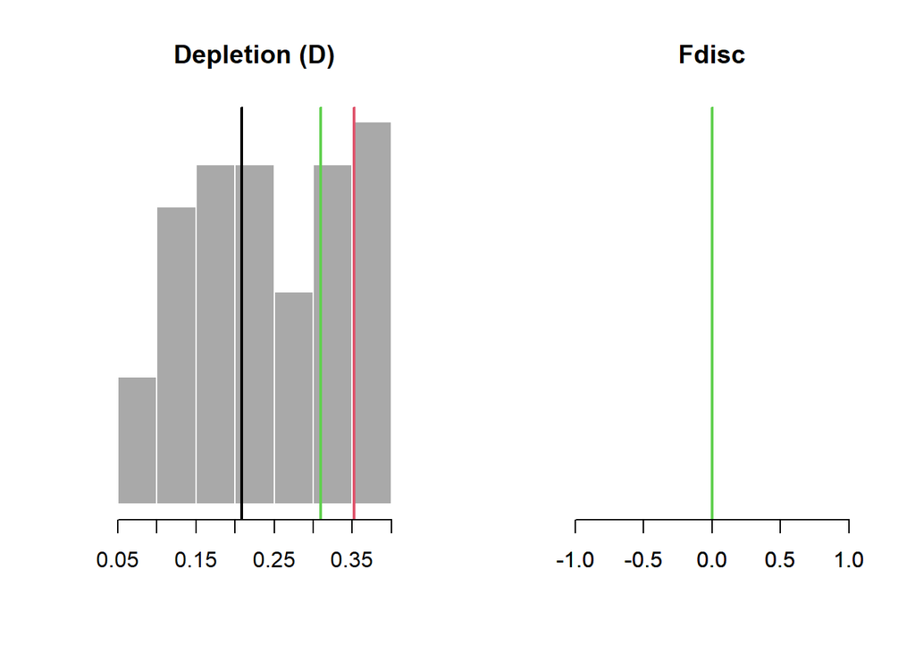

### Length-weight conversion parameters: a, b

**a**: Length-weight parameter alpha. Single value. Positive real number

Specified Value(s): 0.01

Estimated from CDFW data

**b**: Length-weight parameter beta. Single value. Positive real number

Specified Value(s): 1.9

See above

### Spatial distribution and movement: Size_area_1, Frac_area_1, Prob_staying

**Size_area_1**: The size of area 1 relative to area 2. Uniform distribution lower and upper bounds. Positive real numbers

Specified Value(s): 0.15, 0.25

The Size_area_1 slot was not included in DLMtool at the time of this analyis. For this OM this Size_area_1 has been set equal to Frac_area_1 which assumes equal density in Area 1 and Area 2.

**Frac_area_1**: The fraction of the unfished biomass in stock 1. Uniform distribution lower and upper bounds. Positive real numbers

Specified Value(s): 0.15, 0.25

Sea cucumber are mobile and able to move. However, movement rates are not well understood, and the probability of staying in a spatial area was set equal to that used for the red sea urchin.

**Prob_staying**: The probability of individuals in area 1 remaining in area 1 over the course of one year. Uniform distribution lower and upper bounds. Positive fraction.

Specified Value(s): 0.95, 0.99

See above.

### Spatial & Movement

#### Sampled Parameters

Histograms of 48 simulations of size of area 1 (`Size_area_1`), fraction of unfished biomass in area 1 (`Frac_area_1`), and the probability of staying in area 1 in a year (`Frac_area_1`), with vertical colored lines indicating 3 randomly drawn values used in other plots:

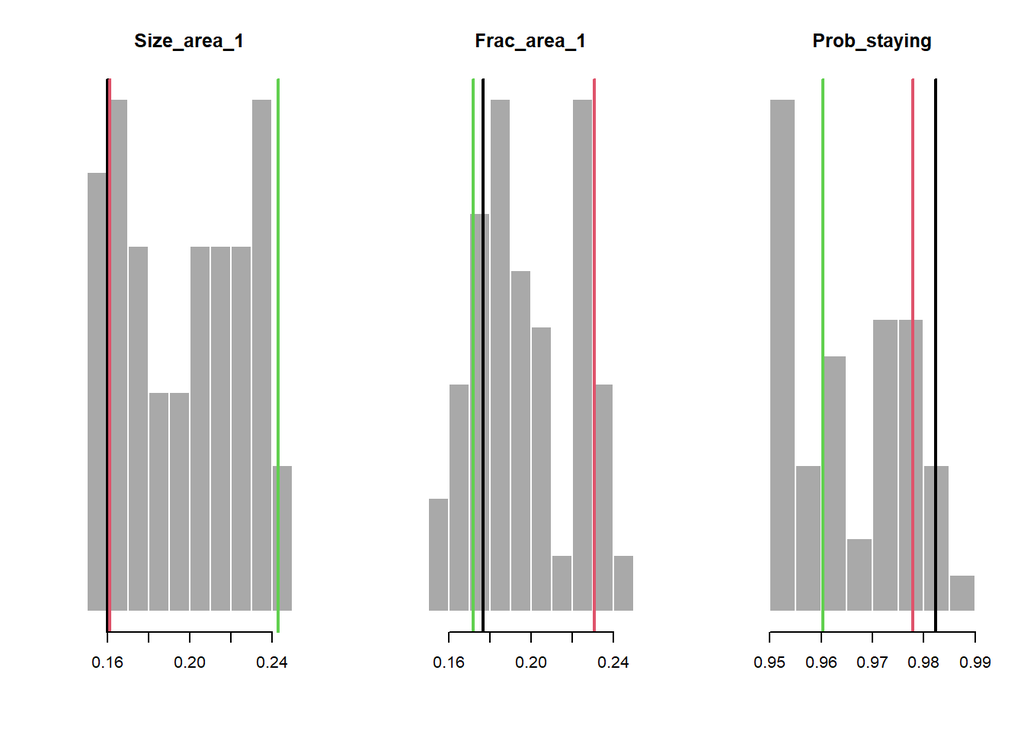

# Fleet Parameters

### Historical years of fishing, spatial targeting: nyears, Spat_targ

**nyears**: The number of years for the historical spool-up simulation. Single value. Positive integer

Specified Value(s): 39

The first catches of sea cucumber in southern California were landed in 1978, and a 39-year historical fishing period (1978 – 2016) was assumed.

**Spat_targ**: Distribution of fishing in relation to spatial biomass: fishing distribution is proportional to B^Spat_targ. Uniform distribution lower and upper bounds. Real numbers

Specified Value(s): 1, 1

Targeting was assumed proportional to biomass.

### Trend in historical fishing effort (exploitation rate), interannual variability in fishing effort: EffYears, EffLower, EffUpper, Esd

**EffYears**: Years representing join-points (vertices) of time-varying effort. Vector. Non-negative real numbers

Fishing mortality appears to have been increasing since the beginning of the fishery 40 years ago. A generally increasing trend in fishing mortality over time, with reasonably larger variability between years, was assumed for the historical fishing mortality.

**EffLower**: Lower bound on relative effort corresponding to EffYears. Vector. Non-negative real numbers

See EffYears

**EffUpper**: Upper bound on relative effort corresponding to EffYears. Vector. Non-negative real numbers

See EffYears

| EffYears | EffLower | EffUpper |
| --- | --- | --- |
| 1978 | 0.0 | 0.0 |
| 1991 | 0.3 | 0.7 |
| 2003 | 0.6 | 1.0 |
| 2016 | 0.6 | 1.0 |

**Esd**: Additional inter-annual variability in fishing mortality rate. Uniform distribution lower and upper bounds. Non-negative real numbers

Specified Value(s): 0.1, 0.4

Default values from DLMtool were used for the inter-annual variability in fishing mortality.

### Historical Effort

#### Sampled Parameters

Histograms of 48 simulations of inter-annual variability in historical fishing mortality (`Esd`), with vertical colored lines indicating 3 randomly drawn values used in the time-series plot:

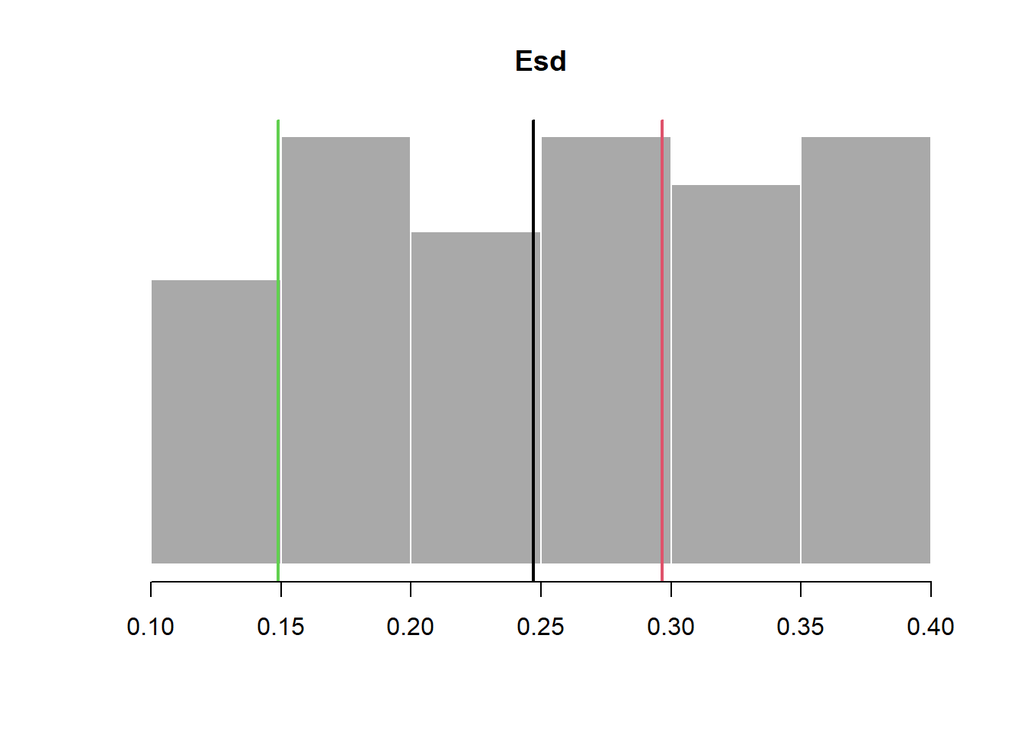

#### Time-Series

Time-series plot showing 3 trends in historical fishing mortality (`OM@EffUpper` and `OM@EffLower` or `OM@cpars$Find`):

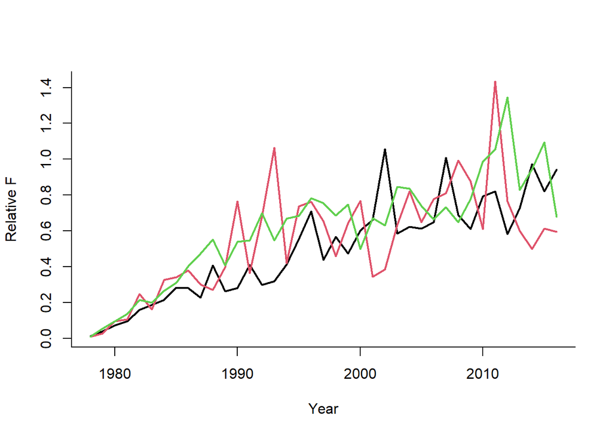

### Annual increase in catchability, interannual variability in catchability: qinc, qcv

**qinc**: Average percentage change in fishing efficiency (applicable only to forward projection and input controls). Uniform distribution lower and upper bounds. Non-negative real numbers

Specified Value(s): 0, 2

Default values from DLMtool were used for the annual increase in catchability.

**qcv**: Inter-annual variability in fishing efficiency (applicable only to forward projection and input controls). Uniform distribution lower and upper bounds. Non-negative real numbers

Specified Value(s): 0.1, 0.3

Default values from DLMtool were used for the annual variability in catchability.

### Future Catchability

#### Sampled Parameters

Histograms of 48 simulations of inter-annual variability in fishing efficiency (`qcv`) and average annual change in fishing efficiency (`qinc`), with vertical colored lines indicating 3 randomly drawn values used in the time-series plot:

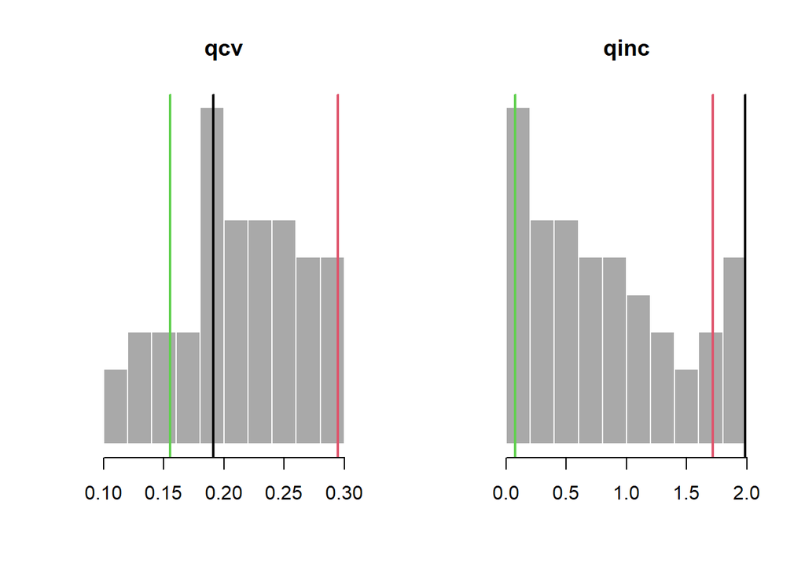

#### Time-Series

Time-series plot showing 3 trends in future fishing efficiency (catchability):

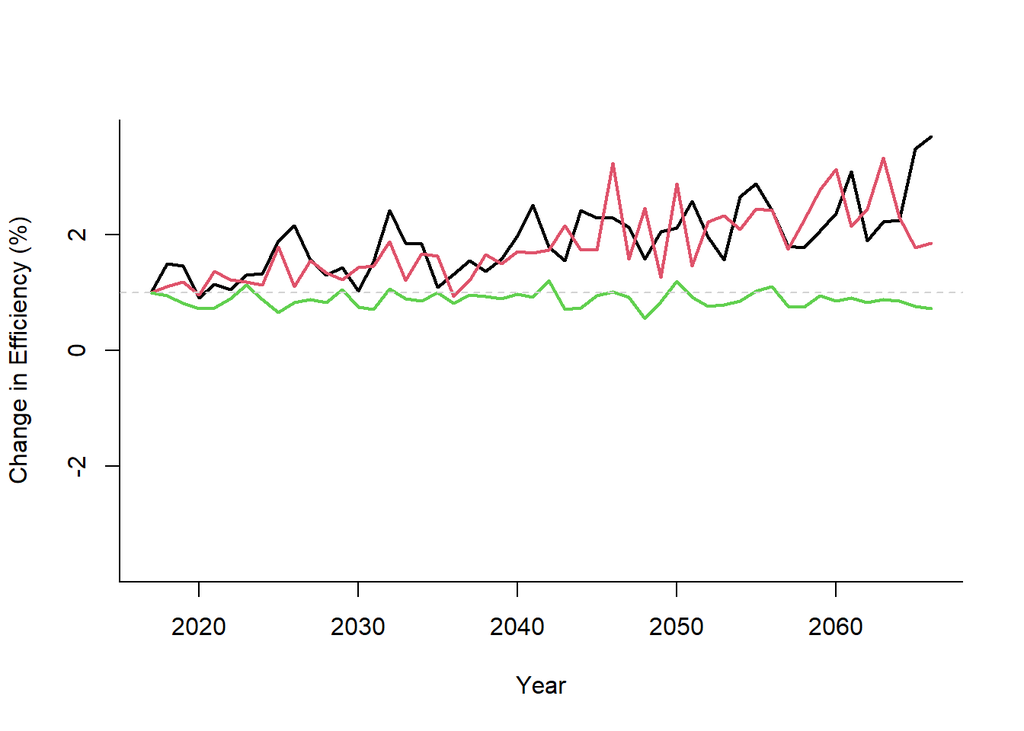

### Fishery gear length selectivity: L5, LFS, Vmaxlen, isRel

**L5**: Shortest length corresponding to 5 percent vulnerability. Uniform distribution lower and upper bounds. Positive real numbers

Specified Value(s): 35, 45

The smallest capture sea cucumbers appear to be about 40 mm contracted length, and the mode of the size distribution is around 90 mm. This information was used to set the bounds for length at 5% selection (L5) at 35 - 45 mm length, and smallest length at full selection (LFS) at 85 - 95 mm.

**LFS**: Shortest length that is fully vulnerable to fishing. Uniform distribution lower and upper bounds. Positive real numbers

Specified Value(s): 85, 95

See L5

**Vmaxlen**: The vulnerability of fish at Stock@Linf . Uniform distribution lower and upper bounds. Fraction

Specified Value(s): 1, 1

There appears to be no evidence or reason to expect dome-shaped selectivity pattern, and the vulnerability at maximum length was set to 1.

**isRel**: Selectivity parameters in units of size-of-maturity (or absolute eg cm). Single value. Boolean

Specified Value(s): FALSE

Selectivity was specified in absolute units.

### Fishery length retention: LR5, LFR, Rmaxlen, DR

**LR5**: Shortest length corresponding ot 5 percent retention. Uniform distribution lower and upper bounds. Non-negative real numbers

Specified Value(s): 0, 0

This slot was not included in DLMtool at the time the OM was built. The retention curve is assumed to be equivalent to the selectivity curve, which is probably a reasonable assumption in this dive fishery.

**LFR**: Shortest length that is fully retained. Uniform distribution lower and upper bounds. Non-negative real numbers

Specified Value(s): 0, 0

See LR5

**Rmaxlen**: The retention of fish at Stock@Linf . Uniform distribution lower and upper bounds. Non-negative real numbers

Specified Value(s): 1, 1

See LR5

**DR**: Discard rate - the fraction of caught fish that are discarded. Uniform distribution lower and upper bounds. Fraction

Specified Value(s): 0, 0

This slot was not included in DLMtool at the time the OM was built. No general discarding was modelled.

### Current Year: CurrentYr

**CurrentYr**: The current calendar year (final year) of the historical simulations (eg 2011). Single value. Positive integer

Specified Value(s): 2016

The most recent data was from 2016

### Existing Spatial Closures: MPA

**MPA**: Is Area 1 currently closed (TRUE) or open (FALSE)? Defaults to FALSE

Specified Value(s): FALSE

This slot was not included in DLMtool at the time the OM was built. Historical MPAs have now been included in recent versions of DLMtool.

# Obs Parameters

Except where information was found to suggest alternative values, the parameters used for the observation model were based on the values presented in Carruthers et al. (2014) and are found in the ‘Generic_Obs’ observation object in the DLMtool.

### Catch statistics: Cobs, Cbiascv, CAA_nsamp, CAA_ESS, CAL_nsamp, CAL_ESS

**Cobs**: Log-normal catch observation error expressed as a coefficient of variation. Uniform distribution lower and upper bounds. Non-negative real numbers

Specified Value(s): 0.1, 0.3

Borrowed from: Generic_Obs

**Cbiascv**: Log-normal coefficient of variation controlling the sampling of bias in catch observations for each simulation. Single value. Non-negative real number

Specified Value(s): 0.1

Borrowed from: Generic_Obs

**CAA_nsamp**: Number of catch-at-age observation per time step. Uniform distribution lower and upper bounds. Positive real numbers

Specified Value(s): 100, 200

Borrowed from: Generic_Obs

**CAA_ESS**: Effective sample size (independent age draws) of the multinomial catch-at-age observation error model. Uniform distribution lower and upper bounds. Positive integers

Specified Value(s): 10, 20

The effective sample size for catch-at-age (CAA_ESS) was reduced reflect the paucity of this type of data.

**CAL_nsamp**: Number of catch-at-length observation per time step. Uniform distribution lower and upper bounds. Positive integers

Specified Value(s): 100, 200

Borrowed from: Generic_Obs

**CAL_ESS**: Effective sample size (independent length draws) of the multinomial catch-at-length observation error model. Uniform distribution lower and upper bounds. Positive integers

Specified Value(s): 25, 50

Borrowed from: Generic_Obs

### Index imprecision, bias and hyperstability: Iobs, Btobs, Btbiascv, beta

**Iobs**: Observation error in the relative abundance indices expressed as a coefficient of variation. Uniform distribution lower and upper bounds. Positive real numbers

Specified Value(s): 0.1, 0.4

Borrowed from: Generic_Obs

**Btobs**: Log-normal coefficient of variation controlling error in observations of current stock biomass among years. Uniform distribution lower and upper bounds. Positive real numbers

Specified Value(s): 0.2, 0.5

Borrowed from: Generic_Obs

**Btbiascv**: Uniform-log bounds for sampling persistent bias in current stock biomass. Uniform-log distribution lower and upper bounds. Positive real numbers

Specified Value(s): 0.33, 3

Borrowed from: Generic_Obs

**beta**: A parameter controlling hyperstability/hyperdepletion where values below 1 lead to hyperstability (an index that decreases slower than true abundance) and values above 1 lead to hyperdepletion (an index that decreases more rapidly than true abundance). Uniform distribution lower and upper bounds. Positive real numbers

Specified Value(s): 0.8, 1.2

The range for the beta parameter was set to 0.8 – 1.2 to reflect the perceived increased reliability of CPUE data for this stock compared to the “Generic_obs” default values.

### Bias in maturity, natural mortality rate and growth parameters: LenMbiascv, Mbiascv, Kbiascv,t0biascv, Linfbiascv

**LenMbiascv**: Log-normal coefficient of variation for sampling persistent bias in length at 50 percent maturity. Single value. Positive real numbers

Specified Value(s): 0.1

Borrowed from: Generic_Obs

**Mbiascv**: Log-normal coefficient of variation for sampling persistent bias in observed natural mortality rate. Single value. Positive real number

Specified Value(s): 0.4

The CV for natural mortality was increased to 40% to reflect high uncertainty in this parameter.

**Kbiascv**: Log-normal coefficient of variation for sampling persistent bias in observed growth parameter K. Single value. Positive real number

Specified Value(s): 0.3

The CV for the growth (Linf and K) parameters was increased to 10% and 30% respectively to reflect high uncertainty in these parameters.

**t0biascv**: Log-normal coefficient of variation for sampling persistent bias in observed t0. Single value. Positive real number

Specified Value(s): 0.1

Borrowed from: Generic_Obs

**Linfbiascv**: Log-normal coefficient of variation for sampling persistent bias in observed maximum length. Single value. Positive real number

Specified Value(s): 0.1

See Kbiascv

### Bias in length at first capture, length at full selection: LFCbiascv, LFSbiascv

**LFCbiascv**: Log-normal coefficient of variation for sampling persistent bias in observed length at first capture. Single value. Positive real number

Specified Value(s): 0.05

Borrowed from: Generic_Obs

**LFSbiascv**: Log-normal coefficient of variation for sampling persistent bias in length-at-full selection. Single value. Positive real number

Specified Value(s): 0.05

Borrowed from: Generic_Obs

### Bias in fishery reference points, unfished biomass, FMSY, FMSY/M ratio, biomass at MSY relative to unfished: FMSY_Mbiascv, BMSY_B0biascv

**FMSY_Mbiascv**: Log-normal coefficient of variation for sampling persistent bias in FMSY/M. Single value. Positive real number

Specified Value(s): 0.2

Borrowed from: Generic_Obs

**BMSY_B0biascv**: Log-normal coefficient of variation for sampling persistent bias in BMSY relative to unfished. Single value. Positive real number

Specified Value(s): 0.2

Borrowed from: Generic_Obs

### Management targets in terms of the index (i.e., model free), the total annual catches and absolute biomass levels: Irefbiascv, Crefbiascv, Brefbiascv

**Irefbiascv**: Log-normal coefficient of variation for sampling persistent bias in relative abundance index at BMSY. Single value. Positive real number

Specified Value(s): 0.2

Borrowed from: Generic_Obs

**Crefbiascv**: Log-normal coefficient of variation for sampling persistent bias in MSY. Single value. Positive real number

Specified Value(s): 0.2

Borrowed from: Generic_Obs

**Brefbiascv**: Log-normal coefficient of variation for sampling persistent bias in BMSY. Single value. Positive real number

Specified Value(s): 0.5

Borrowed from: Generic_Obs

### Depletion bias and imprecision: Dbiascv, Dobs

**Dbiascv**: Log-normal coefficient of variation for sampling persistent bias in stock depletion. Single value. Positive real number

Specified Value(s): 0.5

Borrowed from: Generic_Obs

**Dobs**: Log-normal coefficient of variation controlling error in observations of stock depletion among years. Uniform distribution lower and upper bounds. Positive real numbers

Specified Value(s): 0.05, 0.1

Borrowed from: Generic_Obs

### Recruitment compensation and trend: hbiascv, Recbiascv, sigmaRbiascv

**hbiascv**: Log-normal coefficient of variation for sampling persistent bias in steepness. Single value. Positive real number

Specified Value(s): 0.2

Borrowed from: Generic_Obs

**Recbiascv**: Log-normal coefficient of variation for sampling persistent bias in recent recruitment strength. Uniform distribution lower and upper bounds. Positive real numbers

Specified Value(s): 0.1, 0.3

Borrowed from: Generic_Obs

**sigmaRbiascv**: Log-normal coefficeint of variation for sampling persistent bias in recruitment variability. Single value. Positive real number

Specified Value(s): 0.1

No justification provided.

### Effort: Eobs, Ebiascv

**Eobs**: Log-normal effort observation error expressed as a coefficient of variation. Uniform distribution lower and upper bounds. Non-negative real numbers

Slot not used.

**Ebiascv**: Log-normal coefficient of variation controlling the sampling of bias in effort observations for each simulation. Single value. Non-negative real number

Slot not used.

## Observation Parameters

### Catch Observations

#### Sampled Parameters

Histograms of 48 simulations of inter-annual variability in catch observations (`Csd`) and persistent bias in observed catch (`Cbias`), with vertical colored lines indicating 3 randomly drawn values used in other plots:

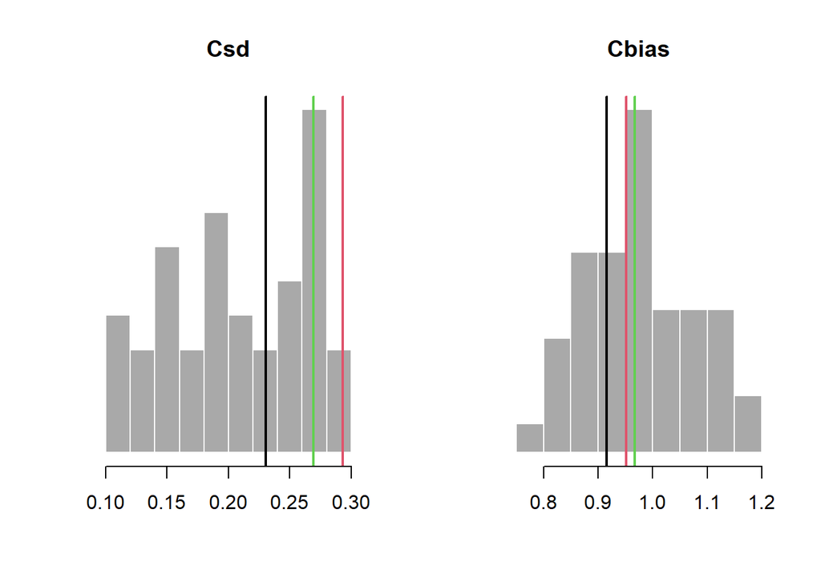

#### Time-Series

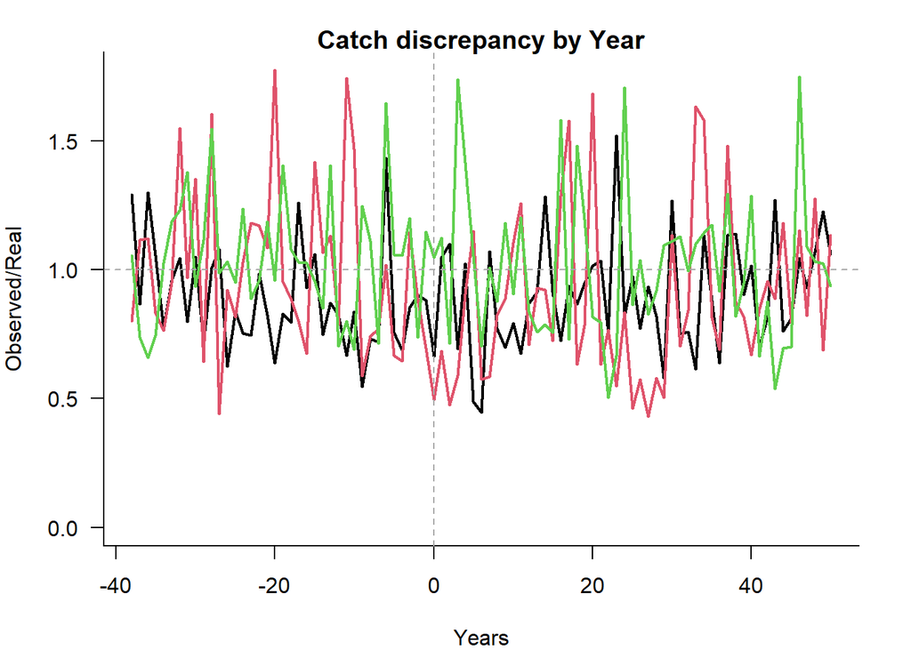

### Depletion Observations

#### Sampled Parameters

Histograms of 48 simulations of inter-annual variability in depletion observations (`Dobs`) and persistent bias in observed depletion (`Dbias`), with vertical colored lines indicating 3 randomly drawn values used in other plots:

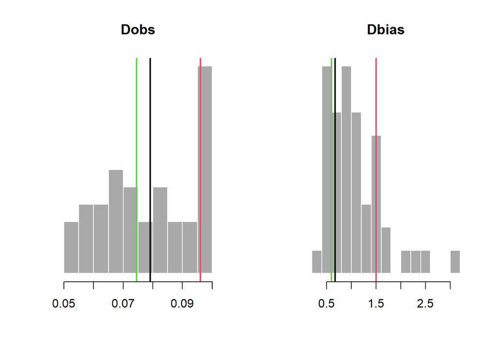

#### Time-Series

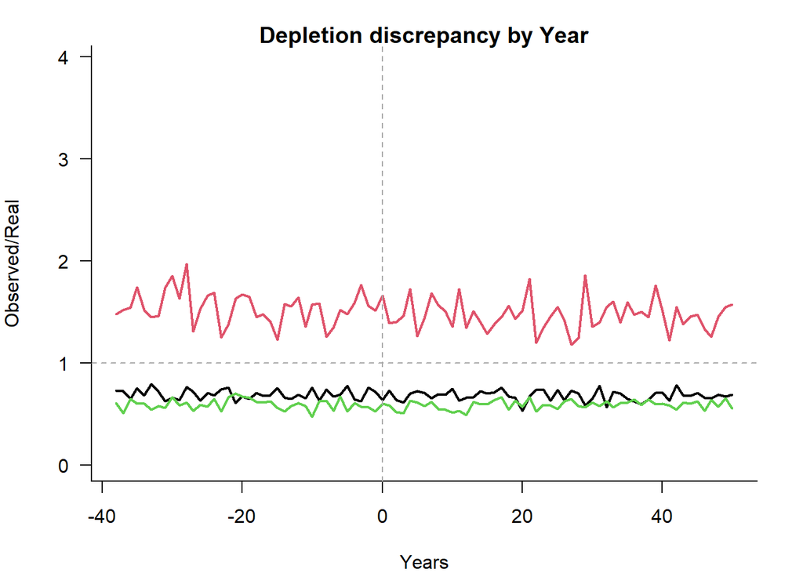

### Abundance Observations

#### Sampled Parameters

Histograms of 48 simulations of inter-annual variability in abundance observations (`Btobs`) and persistent bias in observed abundance (`Btbias`), with vertical colored lines indicating 3 randomly drawn values used in other plots:

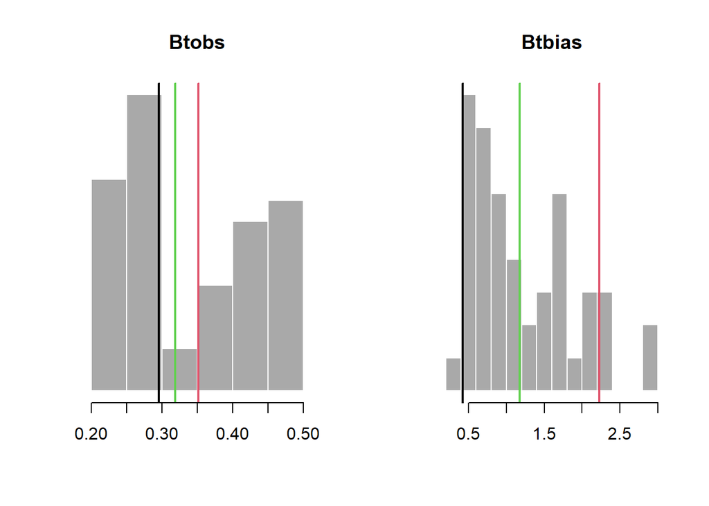

#### Time-Series

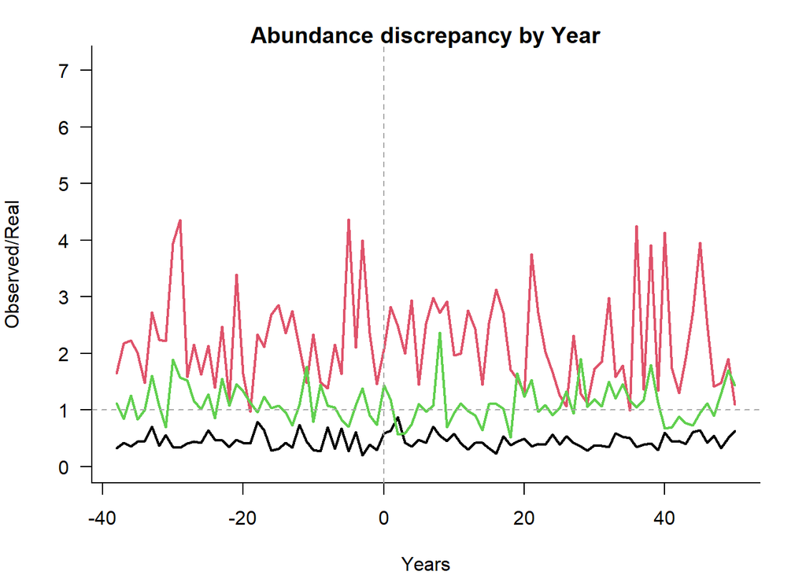

### Index Observations

#### Sampled Parameters

Histograms of 48 simulations of inter-annual variability in index observations (`Iobs`) and hyper-stability/depletion in observed index (`beta`), with vertical colored lines indicating 3 randomly drawn values used in other plots:

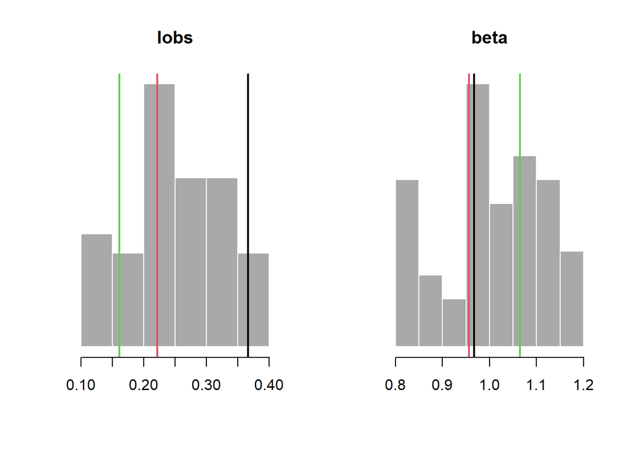

#### Time-Series

Time-series plot of 3 samples of index observation error:

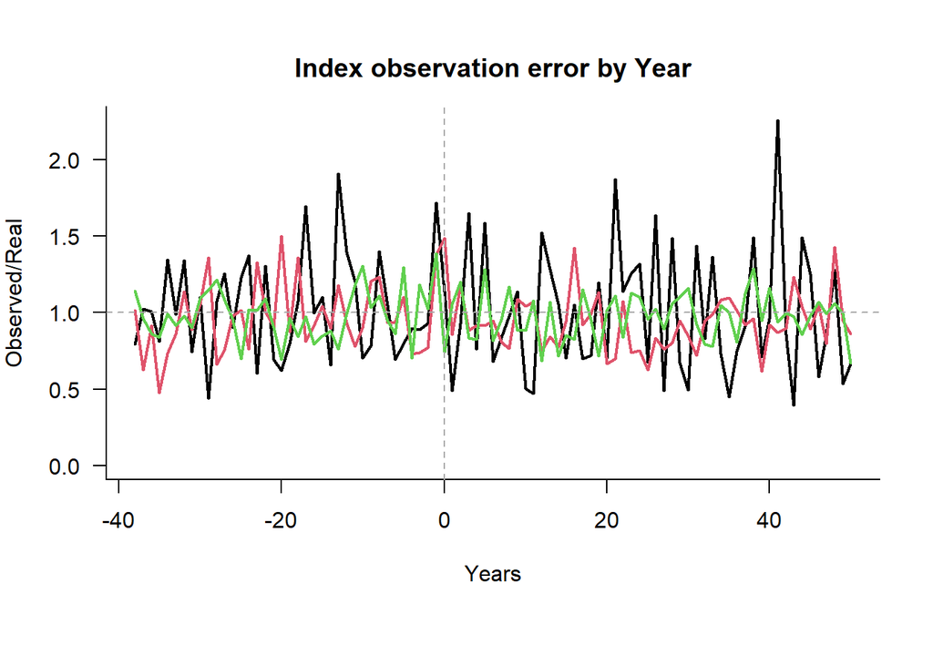

Plot showing an example true abundance index (blue) with 3 samples of index observation error and the hyper-stability/depletion parameter (`beta`):

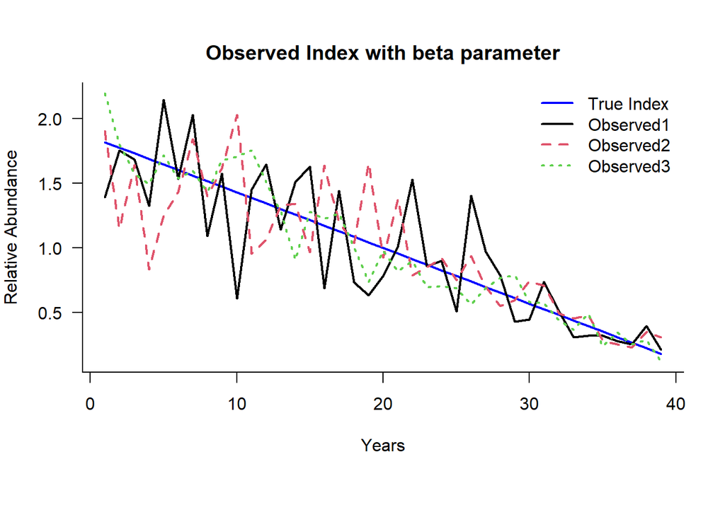

### Recruitment Observations

#### Sampled Parameters

Histograms of 48 simulations of inter-annual variability in index observations (`Recsd`) , with vertical colored lines indicating 3 randomly drawn values used in other plots:

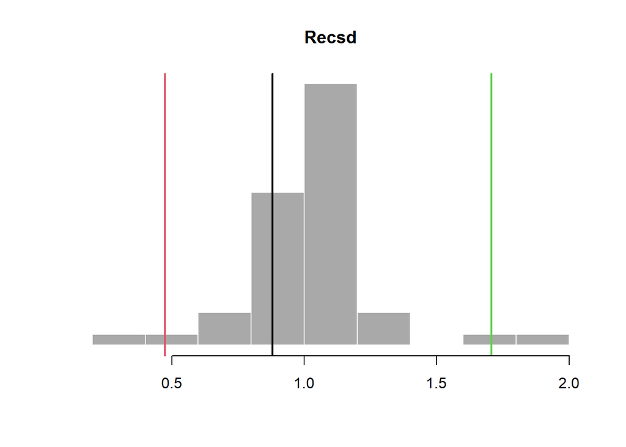

#### Time-Series

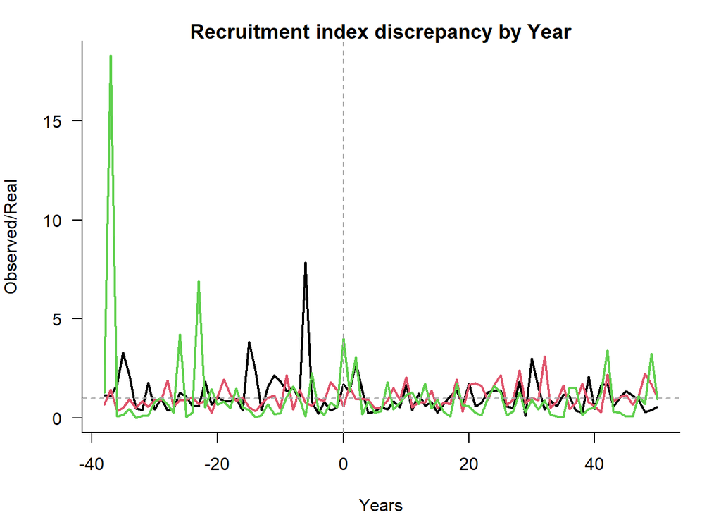

### Composition Observations

#### Sampled Parameters

Histograms of 48 simulations of catch-at-age effective sample size (`CAA_ESS`) and sample size (`CAA_nsamp`) and catch-at-length effective (`CAL_ESS`) and actual sample size (`CAL_nsamp`) with vertical colored lines indicating 3 randomly drawn values:

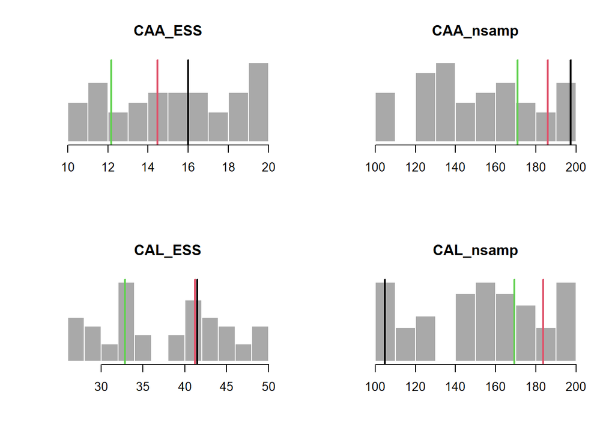

### Parameter Observations

#### Sampled Parameters

Histograms of 48 simulations of bias in observed natural mortality (`Mbias`), von Bertalanffy growth function parameters (`Linfbias`, `Kbias`, and `t0bias`), length-at-maturity (`lenMbias`), and bias in observed length at first capture (`LFCbias`) and first length at full capture (`LFSbias`) with vertical colored lines indicating 3 randomly drawn values:

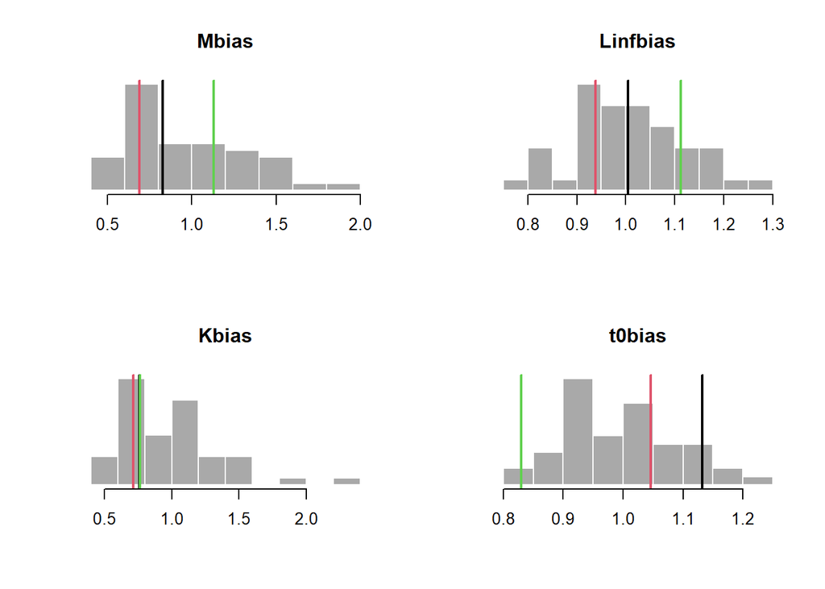

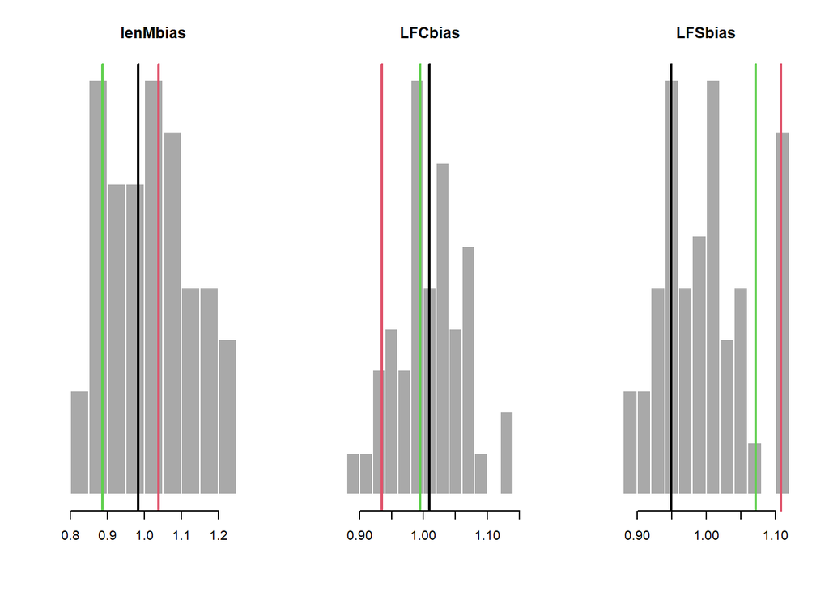